# Study Questions 1, BIOL 126

Prof. Brosi

**=======================================================================**

**PLEASE READ THESE INSTRUCTIONS CAREFULLY BEFORE BEGINNING**

**=======================================================================**

These Study Questions cover all of the problem types you will encounter in Practice Homework 1, Homework 1, and Quiz 1. It is designed to help you understand how to approach the problems, build confidence, and check your understanding before submitting any graded assignments. **Study Questions are the primary way to learn how to do the problems for practice homework, homework, and quiz assignments.** We have intentionally scaffolded our assignments:

- start here with the Study Questions
- when you feel comfortable with solving all of the problem types---after having tried several variations of each (more on that below)---move on to the Practice Homework
  - each of the Study Questions below has 7 variations. See below for how to access the different variants.
- Practice Homeworks are set up to allow you to see what you got wrong, and to submit as many attempts as you would like.
  - But note that if you get one or a few questions wrong, and want to re-submit the Practice Homework, you will have to re-do all of the questions, and you will get new iterations each time you do that.
  - Thus, you will likely **save time by getting familiar with the problems here in the Study Questions** and *then* moving on to the Practice Homework---it's a lot faster to try different iterations here than by doing the *entire* Practice Homework over again each time.
- Homework assignments and Quizzes are similar to the practice assignments, but you can only submit the assignment one time.
  - We recommend studying for the Homework and Quizzes by revisiting these Study Questions.

**We *strongly* recommend watching the relevant lecture videos and completing the readings before attempting problems that seem unfamiliar.** Homework 1 covers content through lecture 2.2.

Please work through these practice problems — and especially read the solution explanations — *before* asking for help with the actual homework.

**What is the alpha diversity of this tide pool community?** The figure shows a single coastal tide pool; the species within the pool are represented by letters (e.g., "a", "b", "c"). *Alpha diversity is species richness, or in other words the count of distinct species present.* **Input an integer (whole number).**

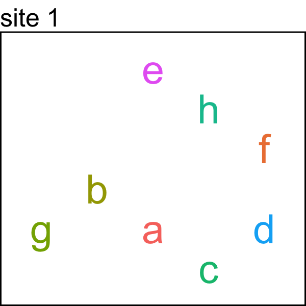

There are **8** species, represented by the letters a, b, c, d, e, f, g, h.

**How to solve this:** Count the number of distinct letters shown in the diagram. Each unique letter represents a different species. There are 8 distinct letters, so the alpha diversity (species richness) = **8**.

Enter only the number — for example, entering "8 species" would be marked incorrect, but entering "8" would be correct.

This problem is intentionally straightforward. The diagram notation (letters = species) is used in more complex diversity problems later in this assignment.

**What is the alpha diversity of this tide pool community?** The figure shows a single coastal tide pool; the species within the pool are represented by letters (e.g., "a", "b", "c"). *Alpha diversity is species richness, or in other words the count of distinct species present.* **Input an integer (whole number).**

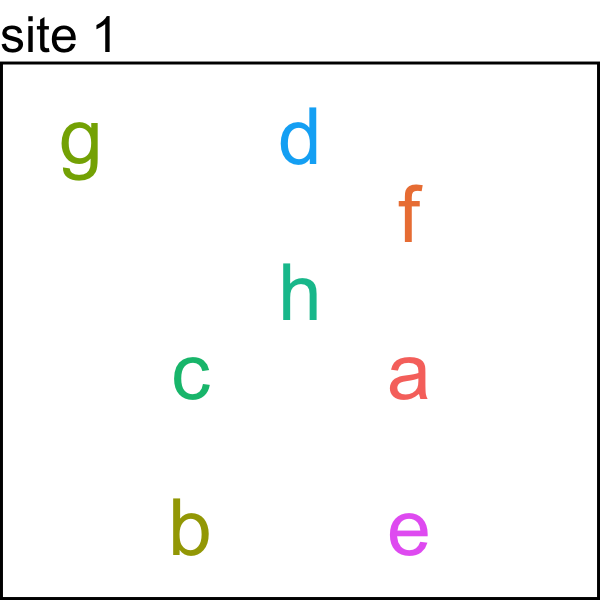

There are **8** species, represented by the letters a, b, c, d, e, f, g, h.

**How to solve this:** Count the number of distinct letters shown in the diagram. Each unique letter represents a different species. There are 8 distinct letters, so the alpha diversity (species richness) = **8**.

Enter only the number — for example, entering "8 species" would be marked incorrect, but entering "8" would be correct.

This problem is intentionally straightforward. The diagram notation (letters = species) is used in more complex diversity problems later in this assignment.

**What is the alpha diversity of this tide pool community?** The figure shows a single coastal tide pool; the species within the pool are represented by letters (e.g., "a", "b", "c"). *Alpha diversity is species richness, or in other words the count of distinct species present.* **Input an integer (whole number).**

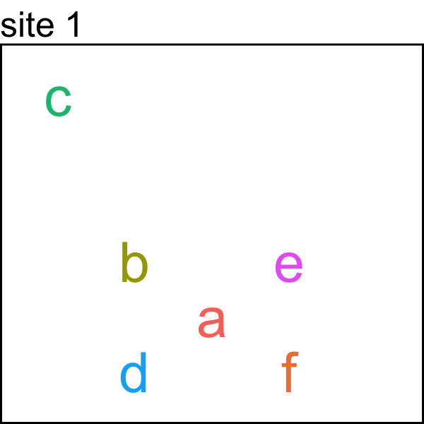

There are **6** species, represented by the letters a, b, c, d, e, f.

**How to solve this:** Count the number of distinct letters shown in the diagram. Each unique letter represents a different species. There are 6 distinct letters, so the alpha diversity (species richness) = **6**.

Enter only the number — for example, entering "6 species" would be marked incorrect, but entering "6" would be correct.

This problem is intentionally straightforward. The diagram notation (letters = species) is used in more complex diversity problems later in this assignment.

**What is the alpha diversity of this tide pool community?** The figure shows a single coastal tide pool; the species within the pool are represented by letters (e.g., "a", "b", "c"). *Alpha diversity is species richness, or in other words the count of distinct species present.* **Input an integer (whole number).**

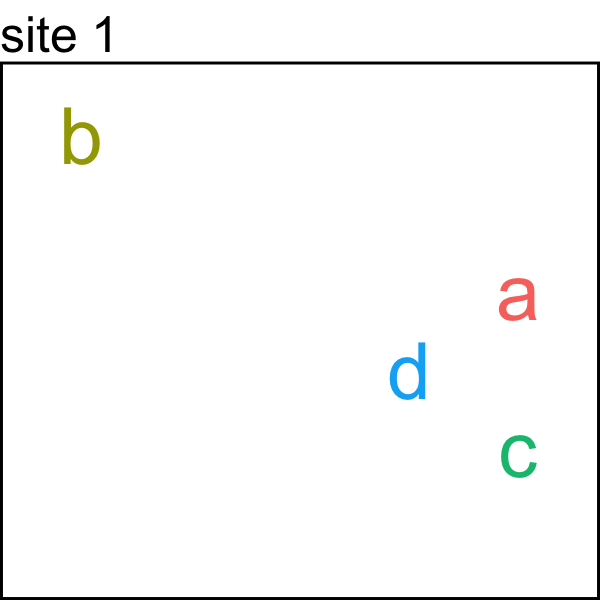

There are **4** species, represented by the letters a, b, c, d.

**How to solve this:** Count the number of distinct letters shown in the diagram. Each unique letter represents a different species. There are 4 distinct letters, so the alpha diversity (species richness) = **4**.

Enter only the number — for example, entering "4 species" would be marked incorrect, but entering "4" would be correct.

This problem is intentionally straightforward. The diagram notation (letters = species) is used in more complex diversity problems later in this assignment.

**What is the alpha diversity of this tide pool community?** The figure shows a single coastal tide pool; the species within the pool are represented by letters (e.g., "a", "b", "c"). *Alpha diversity is species richness, or in other words the count of distinct species present.* **Input an integer (whole number).**

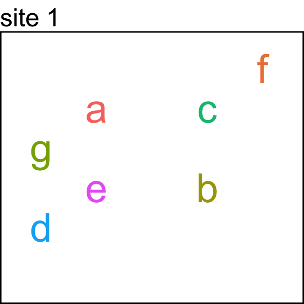

There are **7** species, represented by the letters a, b, c, d, e, f, g.

**How to solve this:** Count the number of distinct letters shown in the diagram. Each unique letter represents a different species. There are 7 distinct letters, so the alpha diversity (species richness) = **7**.

Enter only the number — for example, entering "7 species" would be marked incorrect, but entering "7" would be correct.

This problem is intentionally straightforward. The diagram notation (letters = species) is used in more complex diversity problems later in this assignment.

**What is the alpha diversity of this tide pool community?** The figure shows a single coastal tide pool; the species within the pool are represented by letters (e.g., "a", "b", "c"). *Alpha diversity is species richness, or in other words the count of distinct species present.* **Input an integer (whole number).**

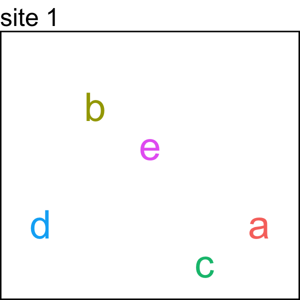

There are **5** species, represented by the letters a, b, c, d, e.

**How to solve this:** Count the number of distinct letters shown in the diagram. Each unique letter represents a different species. There are 5 distinct letters, so the alpha diversity (species richness) = **5**.

Enter only the number — for example, entering "5 species" would be marked incorrect, but entering "5" would be correct.

This problem is intentionally straightforward. The diagram notation (letters = species) is used in more complex diversity problems later in this assignment.

**What is the alpha diversity of this tide pool community?** The figure shows a single coastal tide pool; the species within the pool are represented by letters (e.g., "a", "b", "c"). *Alpha diversity is species richness, or in other words the count of distinct species present.* **Input an integer (whole number).**

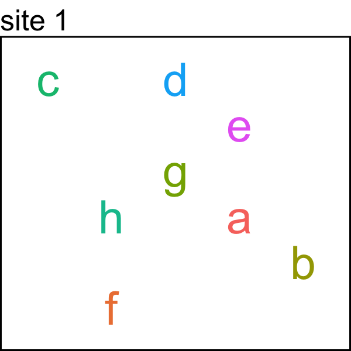

There are **8** species, represented by the letters a, b, c, d, e, f, g, h.

**How to solve this:** Count the number of distinct letters shown in the diagram. Each unique letter represents a different species. There are 8 distinct letters, so the alpha diversity (species richness) = **8**.

Enter only the number — for example, entering "8 species" would be marked incorrect, but entering "8" would be correct.

This problem is intentionally straightforward. The diagram notation (letters = species) is used in more complex diversity problems later in this assignment.

**What is the alpha diversity of this grassland plot?** The figure shows a single grassland survey plot; the plant species within the plot are represented by letters (e.g., "a", "b", "c"). *Alpha diversity is species richness — the count of distinct species present.* **Input an integer (whole number).**

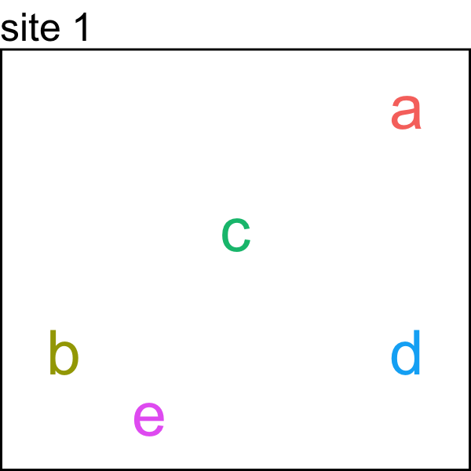

There are **5** species, represented by the letters a, b, c, d, e.

**How to solve this:** Count the distinct letters in the diagram — each unique letter is a different species. There are **5** distinct letters, so alpha diversity = **5**.

Enter only the number (not "5 species") for it to register as correct.

**What is the alpha diversity of this grassland plot?** The figure shows a single grassland survey plot; the plant species within the plot are represented by letters (e.g., "a", "b", "c"). *Alpha diversity is species richness — the count of distinct species present.* **Input an integer (whole number).**

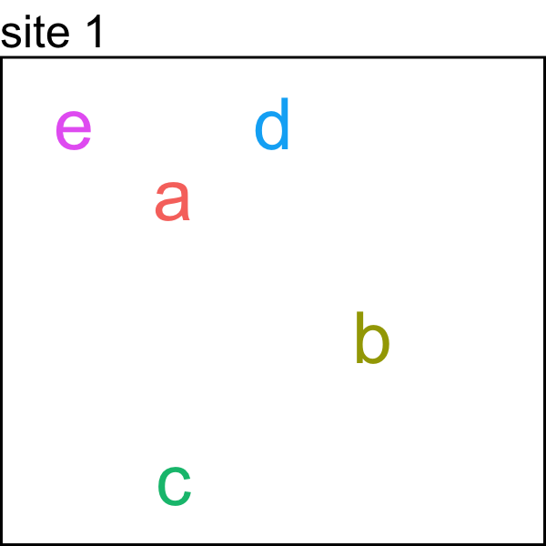

There are **5** species, represented by the letters a, b, c, d, e.

**How to solve this:** Count the distinct letters in the diagram — each unique letter is a different species. There are **5** distinct letters, so alpha diversity = **5**.

Enter only the number (not "5 species") for it to register as correct.

**What is the alpha diversity of this grassland plot?** The figure shows a single grassland survey plot; the plant species within the plot are represented by letters (e.g., "a", "b", "c"). *Alpha diversity is species richness — the count of distinct species present.* **Input an integer (whole number).**

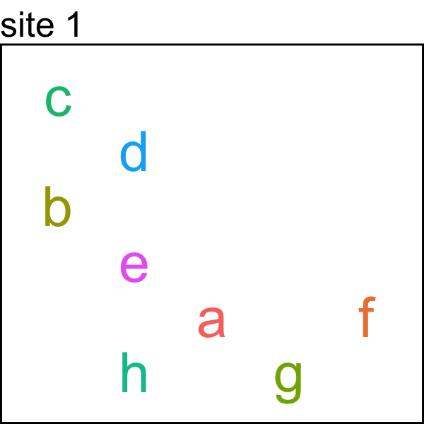

There are **8** species, represented by the letters a, b, c, d, e, f, g, h.

**How to solve this:** Count the distinct letters in the diagram — each unique letter is a different species. There are **8** distinct letters, so alpha diversity = **8**.

Enter only the number (not "8 species") for it to register as correct.

**What is the alpha diversity of this grassland plot?** The figure shows a single grassland survey plot; the plant species within the plot are represented by letters (e.g., "a", "b", "c"). *Alpha diversity is species richness — the count of distinct species present.* **Input an integer (whole number).**

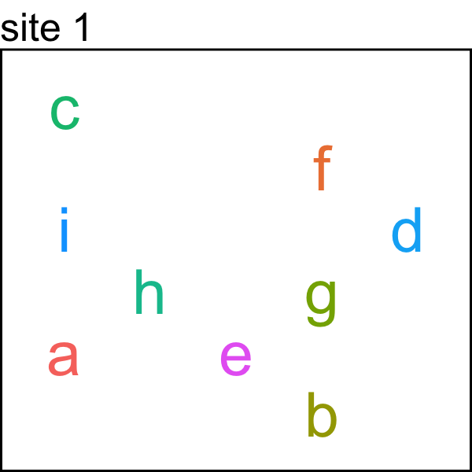

There are **9** species, represented by the letters a, b, c, d, e, f, g, h, i.

**How to solve this:** Count the distinct letters in the diagram — each unique letter is a different species. There are **9** distinct letters, so alpha diversity = **9**.

Enter only the number (not "9 species") for it to register as correct.

**What is the alpha diversity of this grassland plot?** The figure shows a single grassland survey plot; the plant species within the plot are represented by letters (e.g., "a", "b", "c"). *Alpha diversity is species richness — the count of distinct species present.* **Input an integer (whole number).**

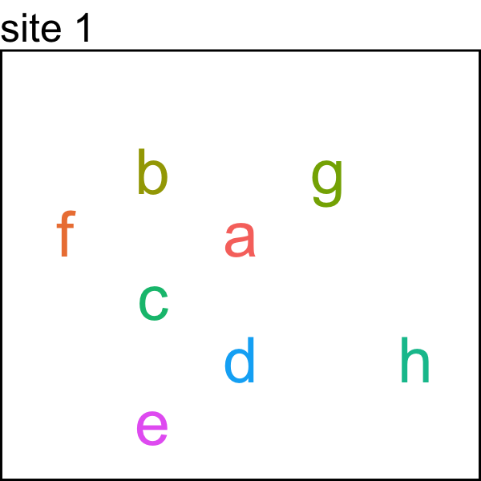

There are **8** species, represented by the letters a, b, c, d, e, f, g, h.

**How to solve this:** Count the distinct letters in the diagram — each unique letter is a different species. There are **8** distinct letters, so alpha diversity = **8**.

Enter only the number (not "8 species") for it to register as correct.

**What is the alpha diversity of this grassland plot?** The figure shows a single grassland survey plot; the plant species within the plot are represented by letters (e.g., "a", "b", "c"). *Alpha diversity is species richness — the count of distinct species present.* **Input an integer (whole number).**

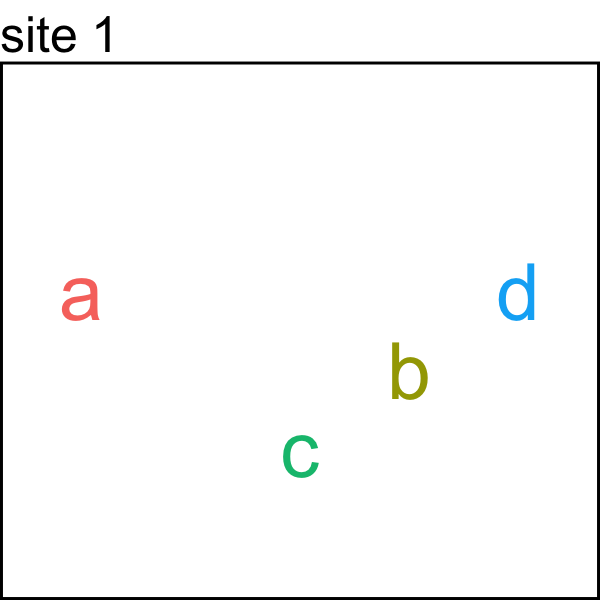

There are **4** species, represented by the letters a, b, c, d.

**How to solve this:** Count the distinct letters in the diagram — each unique letter is a different species. There are **4** distinct letters, so alpha diversity = **4**.

Enter only the number (not "4 species") for it to register as correct.

**What is the alpha diversity of this grassland plot?** The figure shows a single grassland survey plot; the plant species within the plot are represented by letters (e.g., "a", "b", "c"). *Alpha diversity is species richness — the count of distinct species present.* **Input an integer (whole number).**

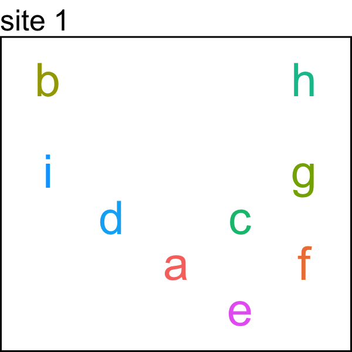

There are **9** species, represented by the letters a, b, c, d, e, f, g, h, i.

**How to solve this:** Count the distinct letters in the diagram — each unique letter is a different species. There are **9** distinct letters, so alpha diversity = **9**.

Enter only the number (not "9 species") for it to register as correct.

**Which site or sites have the highest alpha diversity (species richness)?** The figure shows 4 stream macroinvertebrate communities sampled at different points along a river. The species within each site are represented by letters (e.g., "a", "b", "c"). **Select *all* of the sites with the maximum alpha diversity;** it may be just one site, or it may be two or more.

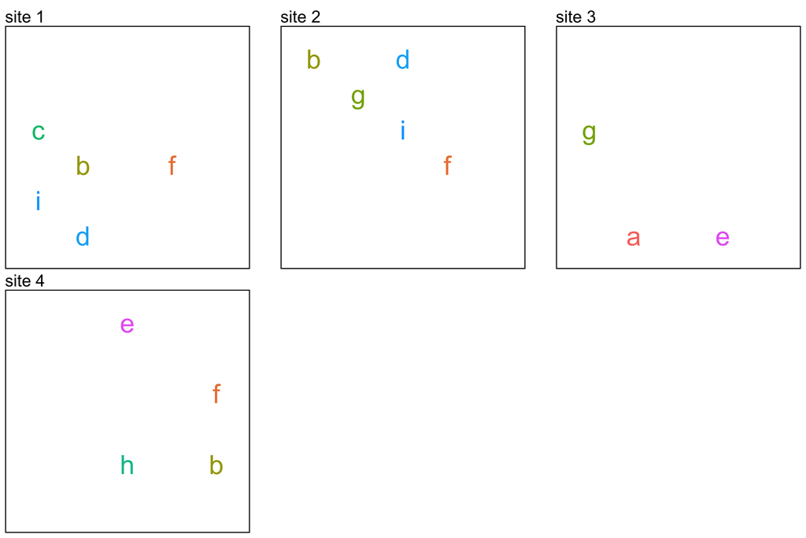

The maximum species richness is **5** species, found in **site 1, site 2**.

**How to solve this:** Count the distinct letters (species) in each site panel.

- Site 1 : 5 species
- Site 2 : 5 species
- Site 3 : 3 species
- Site 4 : 4 species

The site(s) with the highest count — 5 species — is/are **site 1, site 2**.

**Which site or sites have the highest alpha diversity (species richness)?** The figure shows 4 stream macroinvertebrate communities sampled at different points along a river. The species within each site are represented by letters (e.g., "a", "b", "c"). **Select *all* of the sites with the maximum alpha diversity;** it may be just one site, or it may be two or more.

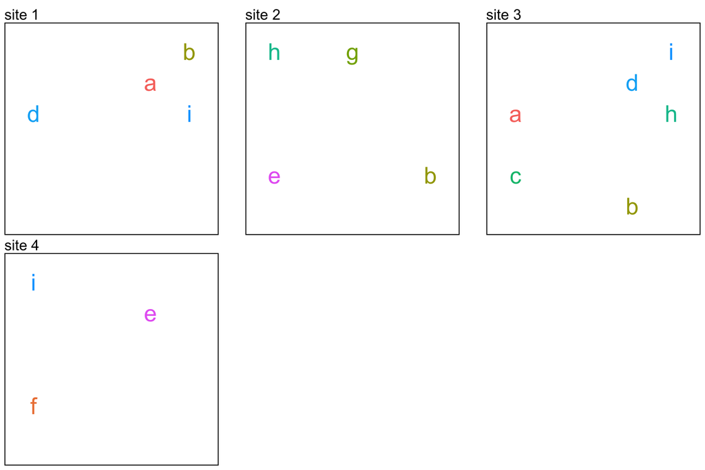

The maximum species richness is **6** species, found in **site 3**.

**How to solve this:** Count the distinct letters (species) in each site panel.

- Site 1 : 4 species
- Site 2 : 4 species
- Site 3 : 6 species
- Site 4 : 3 species

The site(s) with the highest count — 6 species — is/are **site 3**.

**Which site or sites have the highest alpha diversity (species richness)?** The figure shows 4 stream macroinvertebrate communities sampled at different points along a river. The species within each site are represented by letters (e.g., "a", "b", "c"). **Select *all* of the sites with the maximum alpha diversity;** it may be just one site, or it may be two or more.

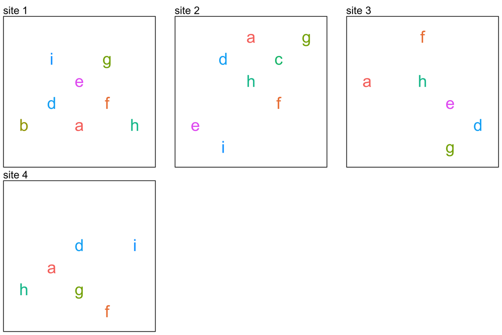

The maximum species richness is **8** species, found in **site 1, site 2**.

**How to solve this:** Count the distinct letters (species) in each site panel.

- Site 1 : 8 species
- Site 2 : 8 species
- Site 3 : 6 species
- Site 4 : 6 species

The site(s) with the highest count — 8 species — is/are **site 1, site 2**.

**Which site or sites have the highest alpha diversity (species richness)?** The figure shows 4 stream macroinvertebrate communities sampled at different points along a river. The species within each site are represented by letters (e.g., "a", "b", "c"). **Select *all* of the sites with the maximum alpha diversity;** it may be just one site, or it may be two or more.

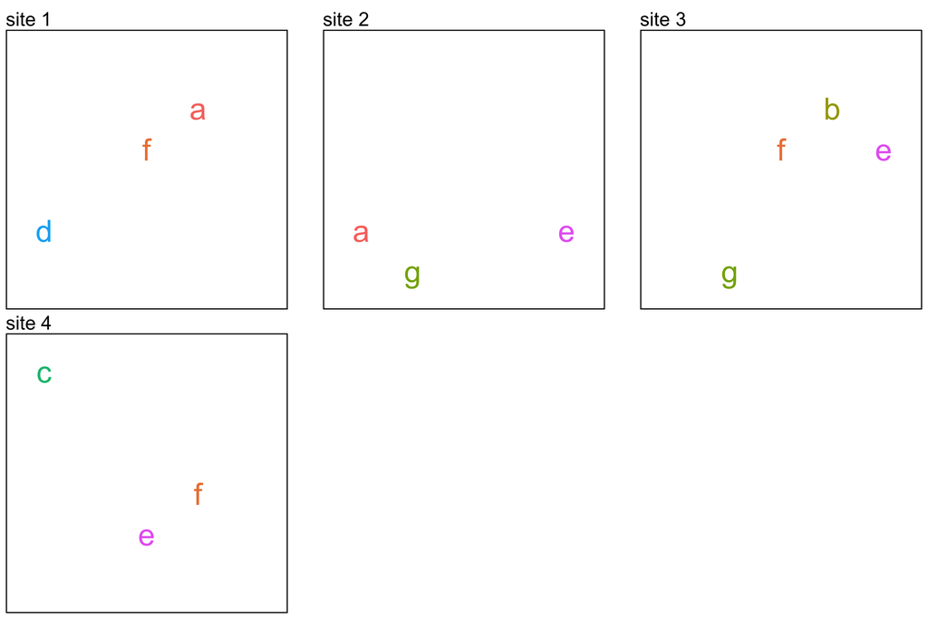

The maximum species richness is **4** species, found in **site 3**.

**How to solve this:** Count the distinct letters (species) in each site panel.

- Site 1 : 3 species
- Site 2 : 3 species
- Site 3 : 4 species
- Site 4 : 3 species

The site(s) with the highest count — 4 species — is/are **site 3**.

**Which site or sites have the highest alpha diversity (species richness)?** The figure shows 4 stream macroinvertebrate communities sampled at different points along a river. The species within each site are represented by letters (e.g., "a", "b", "c"). **Select *all* of the sites with the maximum alpha diversity;** it may be just one site, or it may be two or more.

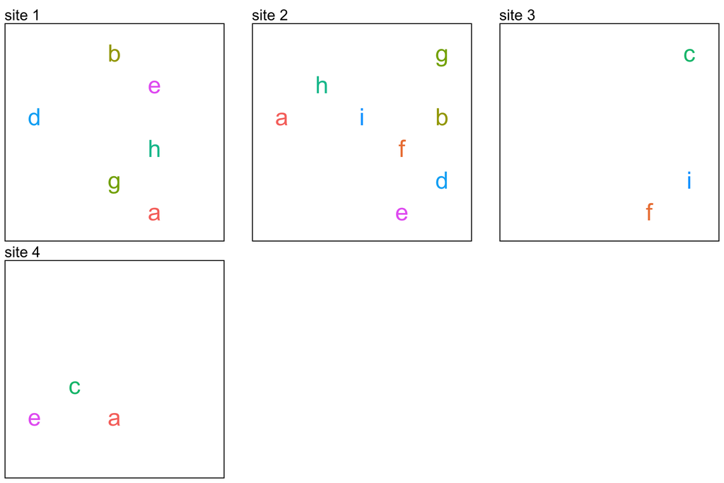

The maximum species richness is **8** species, found in **site 2**.

**How to solve this:** Count the distinct letters (species) in each site panel.

- Site 1 : 6 species
- Site 2 : 8 species
- Site 3 : 3 species
- Site 4 : 3 species

The site(s) with the highest count — 8 species — is/are **site 2**.

**Which site or sites have the highest alpha diversity (species richness)?** The figure shows 4 stream macroinvertebrate communities sampled at different points along a river. The species within each site are represented by letters (e.g., "a", "b", "c"). **Select *all* of the sites with the maximum alpha diversity;** it may be just one site, or it may be two or more.

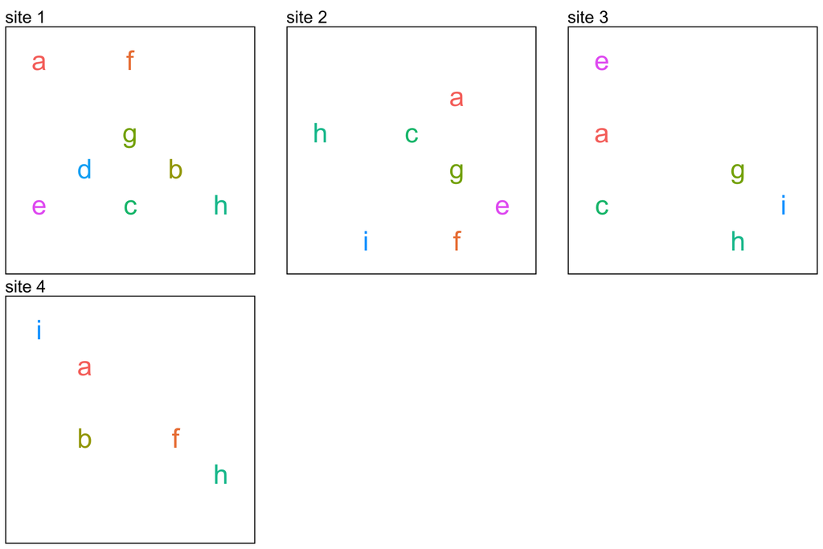

The maximum species richness is **8** species, found in **site 1**.

**How to solve this:** Count the distinct letters (species) in each site panel.

- Site 1 : 8 species
- Site 2 : 7 species
- Site 3 : 6 species
- Site 4 : 5 species

The site(s) with the highest count — 8 species — is/are **site 1**.

**Which site or sites have the highest alpha diversity (species richness)?** The figure shows 4 stream macroinvertebrate communities sampled at different points along a river. The species within each site are represented by letters (e.g., "a", "b", "c"). **Select *all* of the sites with the maximum alpha diversity;** it may be just one site, or it may be two or more.

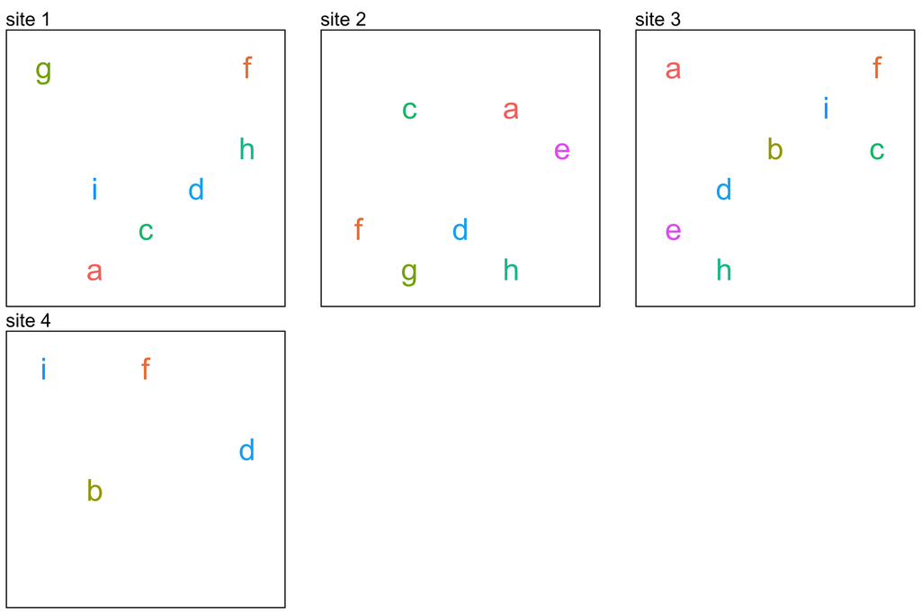

The maximum species richness is **8** species, found in **site 3**.

**How to solve this:** Count the distinct letters (species) in each site panel.

- Site 1 : 7 species
- Site 2 : 7 species
- Site 3 : 8 species
- Site 4 : 4 species

The site(s) with the highest count — 8 species — is/are **site 3**.

**What is the highest alpha diversity (species richness) found in any of the sites below?** The figure shows 3 forest fragment communities. Species are represented by letters (e.g., "a", "b", "c"). Two or more sites may share the same (highest) alpha diversity. **Input an integer** (whole number).

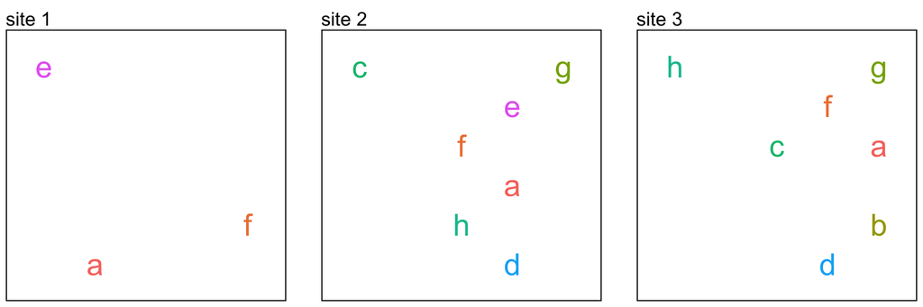

The maximum species richness is **7** species, found in site 2, site 3.

**How to solve this:** Count the distinct species (letters) in each site panel:

- Site 1 : 3 species
- Site 2 : 7 species
- Site 3 : 7 species

The highest value is **7**. Enter only this number — not "7 species", not the site name, just the integer **7**.

**What is the highest alpha diversity (species richness) found in any of the sites below?** The figure shows 3 forest fragment communities. Species are represented by letters (e.g., "a", "b", "c"). Two or more sites may share the same (highest) alpha diversity. **Input an integer** (whole number).

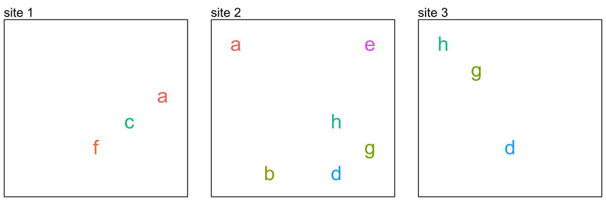

The maximum species richness is **6** species, found in site 2.

**How to solve this:** Count the distinct species (letters) in each site panel:

- Site 1 : 3 species
- Site 2 : 6 species
- Site 3 : 3 species

The highest value is **6**. Enter only this number — not "6 species", not the site name, just the integer **6**.

**What is the highest alpha diversity (species richness) found in any of the sites below?** The figure shows 3 forest fragment communities. Species are represented by letters (e.g., "a", "b", "c"). Two or more sites may share the same (highest) alpha diversity. **Input an integer** (whole number).

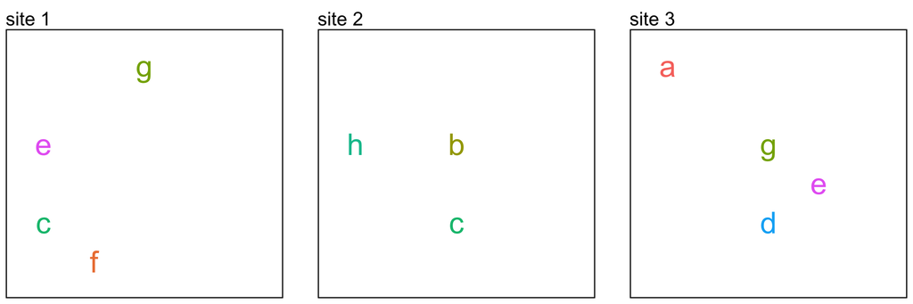

The maximum species richness is **4** species, found in site 1, site 3.

**How to solve this:** Count the distinct species (letters) in each site panel:

- Site 1 : 4 species
- Site 2 : 3 species
- Site 3 : 4 species

The highest value is **4**. Enter only this number — not "4 species", not the site name, just the integer **4**.

**What is the highest alpha diversity (species richness) found in any of the sites below?** The figure shows 3 forest fragment communities. Species are represented by letters (e.g., "a", "b", "c"). Two or more sites may share the same (highest) alpha diversity. **Input an integer** (whole number).

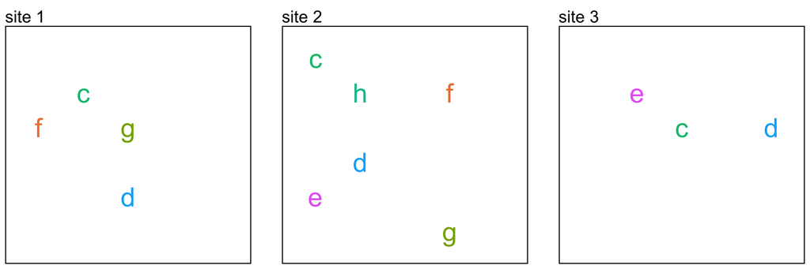

The maximum species richness is **6** species, found in site 2.

**How to solve this:** Count the distinct species (letters) in each site panel:

- Site 1 : 4 species
- Site 2 : 6 species
- Site 3 : 3 species

The highest value is **6**. Enter only this number — not "6 species", not the site name, just the integer **6**.

**What is the highest alpha diversity (species richness) found in any of the sites below?** The figure shows 3 forest fragment communities. Species are represented by letters (e.g., "a", "b", "c"). Two or more sites may share the same (highest) alpha diversity. **Input an integer** (whole number).

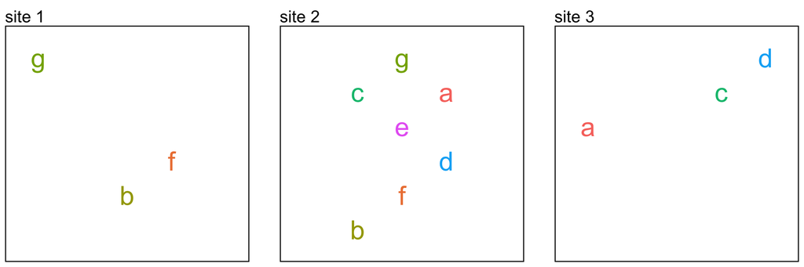

The maximum species richness is **7** species, found in site 2.

**How to solve this:** Count the distinct species (letters) in each site panel:

- Site 1 : 3 species
- Site 2 : 7 species
- Site 3 : 3 species

The highest value is **7**. Enter only this number — not "7 species", not the site name, just the integer **7**.

**What is the highest alpha diversity (species richness) found in any of the sites below?** The figure shows 3 forest fragment communities. Species are represented by letters (e.g., "a", "b", "c"). Two or more sites may share the same (highest) alpha diversity. **Input an integer** (whole number).

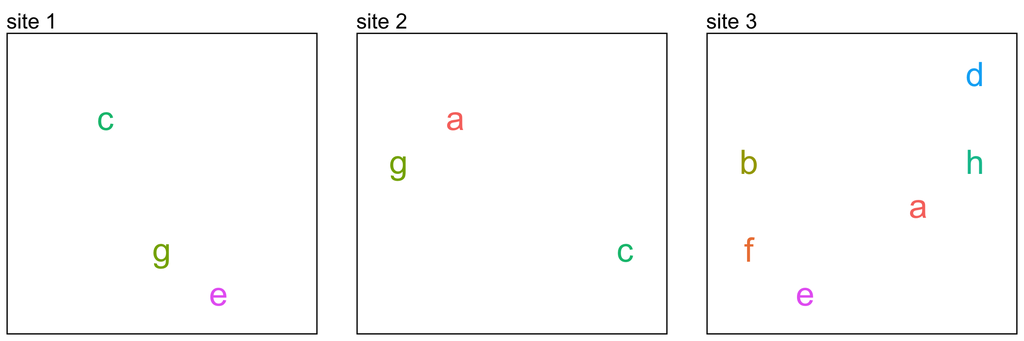

The maximum species richness is **6** species, found in site 3.

**How to solve this:** Count the distinct species (letters) in each site panel:

- Site 1 : 3 species
- Site 2 : 3 species
- Site 3 : 6 species

The highest value is **6**. Enter only this number — not "6 species", not the site name, just the integer **6**.

**What is the highest alpha diversity (species richness) found in any of the sites below?** The figure shows 3 forest fragment communities. Species are represented by letters (e.g., "a", "b", "c"). Two or more sites may share the same (highest) alpha diversity. **Input an integer** (whole number).

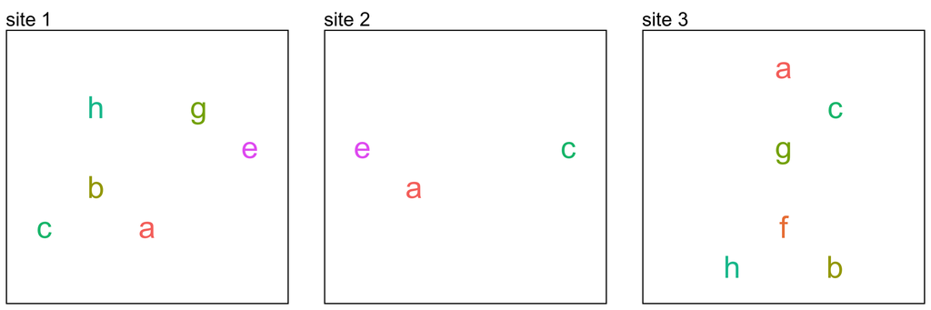

The maximum species richness is **6** species, found in site 1, site 3.

**How to solve this:** Count the distinct species (letters) in each site panel:

- Site 1 : 6 species
- Site 2 : 3 species
- Site 3 : 6 species

The highest value is **6**. Enter only this number — not "6 species", not the site name, just the integer **6**.

**Calculate the *average* alpha diversity between these two wetland sites.** We define "average" as the arithmetic mean: sum the species richness of each site and divide by the number of sites (2). If site 1 has richness $S_1$ and site 2 has richness $S_2$, the mean alpha is $(S_1 + S_2) \div 2$.

Note: the mean alpha diversity is *not* the count of unique species across both sites combined — it is the sum of each site's own richness, divided by the number of sites. Shared species count separately in each site's richness.

**Input a numeric value; round to one decimal place.** If the answer is a whole number, still write $.0$ (e.g., $6.0$).

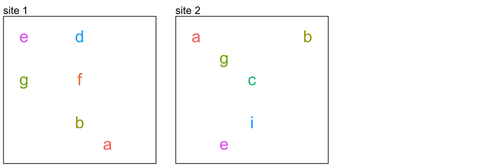

The average (mean) alpha diversity is **6** species.

**Step-by-step:**

- Site 1 has 6 species.
- Site 2 has 6 species.
- Mean alpha $= (S_1 + S_2) \div 2 = (6 + 6) \div 2 = 12 \div 2 = 6$

**Calculate the *average* alpha diversity between these two wetland sites.** We define "average" as the arithmetic mean: sum the species richness of each site and divide by the number of sites (2). If site 1 has richness $S_1$ and site 2 has richness $S_2$, the mean alpha is $(S_1 + S_2) \div 2$.

Note: the mean alpha diversity is *not* the count of unique species across both sites combined — it is the sum of each site's own richness, divided by the number of sites. Shared species count separately in each site's richness.

**Input a numeric value; round to one decimal place.** If the answer is a whole number, still write $.0$ (e.g., $6.0$).

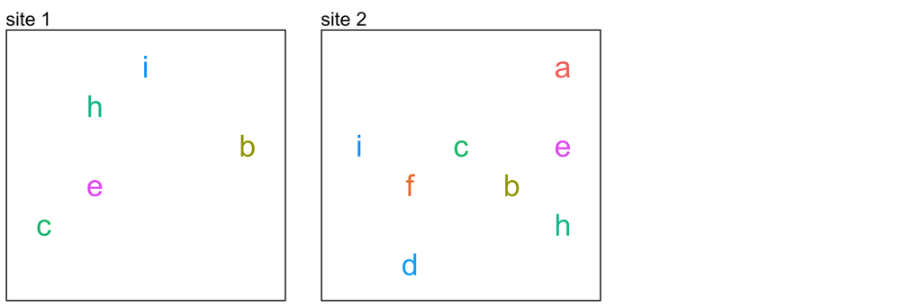

The average (mean) alpha diversity is **6.5** species.

**Step-by-step:**

- Site 1 has 5 species.
- Site 2 has 8 species.
- Mean alpha $= (S_1 + S_2) \div 2 = (5 + 8) \div 2 = 13 \div 2 = 6.5$

Key reminder: even if some species appear in both sites, each site's richness is counted independently. Enter only the numeric value **6.5** for it to register as correct.

**Calculate the *average* alpha diversity between these two wetland sites.** We define "average" as the arithmetic mean: sum the species richness of each site and divide by the number of sites (2). If site 1 has richness $S_1$ and site 2 has richness $S_2$, the mean alpha is $(S_1 + S_2) \div 2$.

Note: the mean alpha diversity is *not* the count of unique species across both sites combined — it is the sum of each site's own richness, divided by the number of sites. Shared species count separately in each site's richness.

**Input a numeric value; round to one decimal place.** If the answer is a whole number, still write $.0$ (e.g., $6.0$).

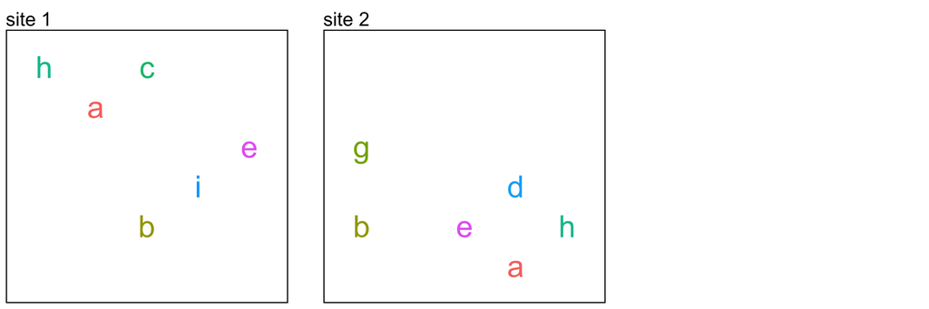

The average (mean) alpha diversity is **6** species.

**Step-by-step:**

- Site 1 has 6 species.
- Site 2 has 6 species.
- Mean alpha $= (S_1 + S_2) \div 2 = (6 + 6) \div 2 = 12 \div 2 = 6$

**Calculate the *average* alpha diversity between these two wetland sites.** We define "average" as the arithmetic mean: sum the species richness of each site and divide by the number of sites (2). If site 1 has richness $S_1$ and site 2 has richness $S_2$, the mean alpha is $(S_1 + S_2) \div 2$.

Note: the mean alpha diversity is *not* the count of unique species across both sites combined — it is the sum of each site's own richness, divided by the number of sites. Shared species count separately in each site's richness.

**Input a numeric value; round to one decimal place.** If the answer is a whole number, still write $.0$ (e.g., $6.0$).

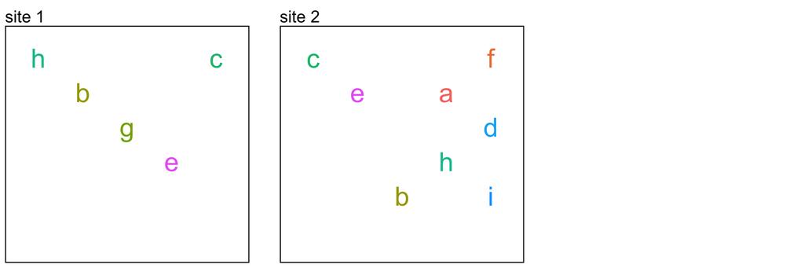

The average (mean) alpha diversity is **6.5** species.